# 05 — Model Improvements

The v1 model (from notebook 04) never predicts above ~6 points. Here we diagnose why and fix it.

**Fix:** Filter training data to only include gameweeks where the player actually played (minutes > 0). This shifts the target distribution from mean ~1.2 to something more representative of actual on-pitch output.

```python
import sys
from pathlib import Path
import json
import pandas as pd
import numpy as np
import matplotlib.pyplot as plt
from sklearn.linear_model import LinearRegression
from sklearn.ensemble import RandomForestRegressor
from xgboost import XGBRegressor
from sklearn.metrics import mean_absolute_error, root_mean_squared_error, r2_score
import joblib

project_root = Path.cwd().parent
if str(project_root) not in sys.path:
    sys.path.append(str(project_root))

plt.style.use('ggplot')
pd.set_option('display.max_columns', 40)
```

## 1. Load fresh data and rebuild features

Using `build_features()` from the prediction pipeline to get the full gameweek DataFrame with raw columns intact.

```python
from src.fpl.predict import build_features

gw_df = build_features()
print(f'Total gameweek records: {len(gw_df):,}')
print(f'Unique players: {gw_df["player_id"].nunique()}')
print(f'Gameweek range: {gw_df["round"].min()} - {gw_df["round"].max()}')
```

```
Total gameweek records: 22,501
Unique players: 820
Gameweek range: 1 - 29
```

## 2. The problem: target distribution

Let's see why the v1 model can't predict above ~6 points.

```
Zero-point records: 14,041 (62.4%)
Records where player played (min > 0): 8,864 (39.4%)
Records where player did NOT play: 13,637 (60.6%)
```

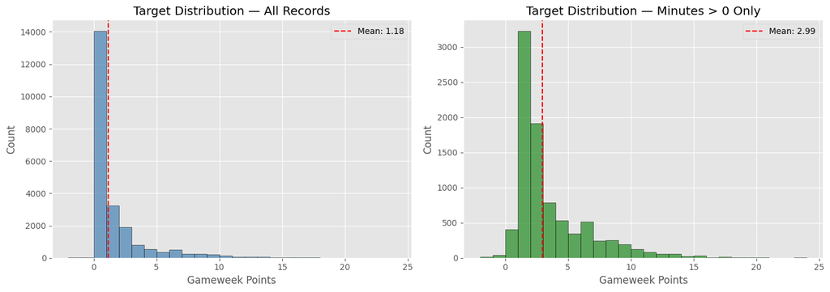

```
Mean points (all): 1.18
Mean points (played only): 2.99
Median points (played only): 2.0
95th percentile (played only): 9.0
```

```python
fig, axes = plt.subplots(1, 2, figsize=(14, 5))

# Full distribution
target = gw_df['target']
axes[0].hist(target, bins=range(-2, 25), edgecolor='black', alpha=0.7, color='steelblue')
axes[0].set_title('Target Distribution — All Records')
axes[0].set_xlabel('Gameweek Points')
axes[0].set_ylabel('Count')
axes[0].axvline(target.mean(), color='red', linestyle='--', label=f'Mean: {target.mean():.2f}')
axes[0].legend()

# Breakdown
zeros = (target == 0).sum()
played = (gw_df['minutes'] > 0).sum()
print(f'Zero-point records: {zeros:,} ({zeros/len(target)*100:.1f}%)')
print(f'Records where player played (min > 0): {played:,} ({played/len(target)*100:.1f}%)')
print(f'Records where player did NOT play: {len(target)-played:,} ({(len(target)-played)/len(target)*100:.1f}%)')

# Distribution for played-only
played_target = target[gw_df['minutes'] > 0]
axes[1].hist(played_target, bins=range(-2, 25), edgecolor='black', alpha=0.7, color='forestgreen')
axes[1].set_title('Target Distribution — Minutes > 0 Only')
axes[1].set_xlabel('Gameweek Points')
axes[1].set_ylabel('Count')
axes[1].axvline(played_target.mean(), color='red', linestyle='--', label=f'Mean: {played_target.mean():.2f}')
axes[1].legend()

plt.tight_layout()
plt.show()

print(f'\nMean points (all): {target.mean():.2f}')
print(f'Mean points (played only): {played_target.mean():.2f}')
print(f'Median points (played only): {played_target.median():.1f}')
print(f'95th percentile (played only): {played_target.quantile(0.95):.1f}')
```

## 3. Prepare filtered feature matrix

Drop rows where the player had 0 minutes, then apply the same time-based split.

```python
# Feature columns (same as notebook 04)
id_cols = ['player_id', 'web_name', 'position', 'team_name', 'round']
target_col = 'target'
exclude = id_cols + [target_col, 'minutes', 'total_points', 'value', 'kickoff_time',
                     'id', 'code', 'element_type_y', 'team', 'price_prev', 'prev_kickoff']

# Use the same feature columns as notebook 04 (load from saved metadata)
with open(project_root / 'models' / 'model_metadata.json') as f:
    old_metadata = json.load(f)

feature_cols = old_metadata['feature_columns']
print(f'Features: {len(feature_cols)}')

# Filter: only rows where player actually played
df_all = gw_df.dropna(subset=feature_cols + [target_col]).copy()
df_played = df_all[df_all['minutes'] > 0].copy()

print(f'All records (with features): {len(df_all):,}')
print(f'Played records (min > 0):    {len(df_played):,} ({len(df_played)/len(df_all)*100:.1f}%)')
```

```
Features: 43
All records (with features): 20,044
Played records (min > 0):    7,853 (39.2%)
```

```python
# Time-based split — same cutoff as notebook 04
TRAIN_END_GW = 22

# V1: all data (reproducing notebook 04)
train_v1 = df_all[df_all['round'] <= TRAIN_END_GW]
test_v1 = df_all[df_all['round'] > TRAIN_END_GW]

# V2: played-only data
train_v2 = df_played[df_played['round'] <= TRAIN_END_GW]
test_v2 = df_played[df_played['round'] > TRAIN_END_GW]

print('=== V1 (all data) ===')
print(f'Train: {len(train_v1):,} rows, target mean: {train_v1[target_col].mean():.2f}')
print(f'Test:  {len(test_v1):,} rows, target mean: {test_v1[target_col].mean():.2f}')

print(f'\n=== V2 (played only) ===')
print(f'Train: {len(train_v2):,} rows, target mean: {train_v2[target_col].mean():.2f}')
print(f'Test:  {len(test_v2):,} rows, target mean: {test_v2[target_col].mean():.2f}')
```

```
=== V1 (all data) ===
Train: 14,175 rows, target mean: 1.21
Test:  5,869 rows, target mean: 1.08

=== V2 (played only) ===
Train: 5,682 rows, target mean: 3.02
Test:  2,171 rows, target mean: 2.92
```

## 4. Train models on both datasets

Same three models, same hyperparameters — only the training data changes.

```python
def train_and_evaluate(train_df, test_df, feature_cols, target_col, label):
    X_train, y_train = train_df[feature_cols], train_df[target_col]
    X_test, y_test = test_df[feature_cols], test_df[target_col]

    models = {
        'Linear Regression': LinearRegression(),
        'Random Forest': RandomForestRegressor(
            n_estimators=200, max_depth=10, min_samples_leaf=20,
            random_state=42, n_jobs=-1
        ),
        'XGBoost': XGBRegressor(
            n_estimators=300, max_depth=6, learning_rate=0.05,
            subsample=0.8, colsample_bytree=0.8,
            random_state=42, n_jobs=-1
        ),
    }

    results = {}
    trained = {}
    for name, model in models.items():
        model.fit(X_train, y_train)
        trained[name] = model
        y_pred = model.predict(X_test)
        results[name] = {
            'MAE': mean_absolute_error(y_test, y_pred),
            'RMSE': root_mean_squared_error(y_test, y_pred),
            'R\u00b2': r2_score(y_test, y_pred),
        }

    results_df = pd.DataFrame(results).T.round(3)
    print(f'\n=== {label} ===')
    print(results_df.to_string())
    return results_df, trained

print('Training on V1 (all data)...')
results_v1, models_v1 = train_and_evaluate(train_v1, test_v1, feature_cols, target_col, 'V1: All Data')

print('\nTraining on V2 (played only)...')
results_v2, models_v2 = train_and_evaluate(train_v2, test_v2, feature_cols, target_col, 'V2: Played Only')
```

```
Training on V1 (all data)...
```

```
=== V1: All Data ===
                     MAE   RMSE     R²
Linear Regression  1.021  1.878  0.321
Random Forest      0.991  1.889  0.313
XGBoost            1.017  1.935  0.280

Training on V2 (played only)...
```

```
=== V2: Played Only ===
                     MAE   RMSE     R²
Linear Regression  2.206  2.851  0.063
Random Forest      2.208  2.871  0.050
XGBoost            2.244  2.921  0.016
```

## 5. Side-by-side comparison

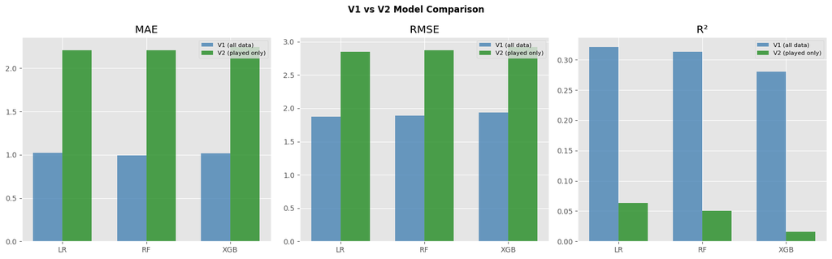

```
=== Improvement (V2 vs V1) ===
Linear Regression     MAE: -1.185  R²: -0.258
Random Forest         MAE: -1.217  R²: -0.263
XGBoost               MAE: -1.227  R²: -0.264
```

```python
fig, axes = plt.subplots(1, 3, figsize=(16, 5))
metrics = ['MAE', 'RMSE', 'R\u00b2']
colors_v1 = ['#6c8ebf', '#6c8ebf', '#6c8ebf']
colors_v2 = ['#82b366', '#82b366', '#82b366']

for i, metric in enumerate(metrics):
    x = np.arange(3)
    width = 0.35
    axes[i].bar(x - width/2, results_v1[metric], width, label='V1 (all data)', color='steelblue', alpha=0.8)
    axes[i].bar(x + width/2, results_v2[metric], width, label='V2 (played only)', color='forestgreen', alpha=0.8)
    axes[i].set_title(metric)
    axes[i].set_xticks(x)
    axes[i].set_xticklabels(['LR', 'RF', 'XGB'], rotation=0)
    axes[i].legend(fontsize=8)

plt.suptitle('V1 vs V2 Model Comparison', fontweight='bold')
plt.tight_layout()
plt.show()

# Improvement summary
print('=== Improvement (V2 vs V1) ===')
for model_name in results_v1.index:
    mae_diff = results_v1.loc[model_name, 'MAE'] - results_v2.loc[model_name, 'MAE']
    r2_diff = results_v2.loc[model_name, 'R\u00b2'] - results_v1.loc[model_name, 'R\u00b2']
    print(f'{model_name:20s}  MAE: {mae_diff:+.3f}  R\u00b2: {r2_diff:+.3f}')
```

## 6. Prediction distribution comparison

The key question: does V2 produce more realistic prediction ranges?

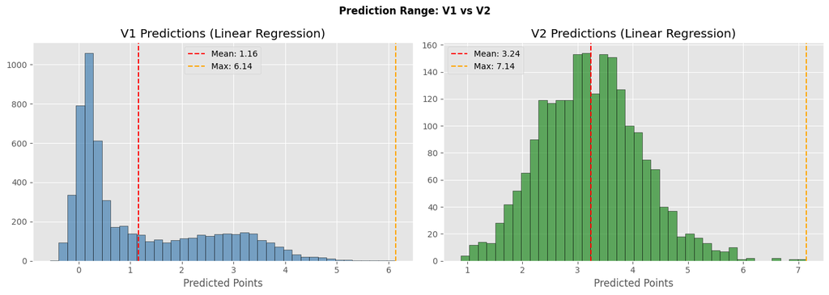

```
V1 prediction range: -0.55 to 6.14 (mean 1.16)
V2 prediction range: 0.89 to 7.14 (mean 3.24)

V1 predictions > 5: 15
V2 predictions > 5: 77
```

```python
best_name_v2 = results_v2['MAE'].idxmin()
best_v1 = models_v1[best_name_v2]
best_v2 = models_v2[best_name_v2]

preds_v1 = best_v1.predict(test_v1[feature_cols])
preds_v2 = best_v2.predict(test_v2[feature_cols])

fig, axes = plt.subplots(1, 2, figsize=(14, 5))

axes[0].hist(preds_v1, bins=40, edgecolor='black', alpha=0.7, color='steelblue')
axes[0].set_title(f'V1 Predictions ({best_name_v2})')
axes[0].set_xlabel('Predicted Points')
axes[0].axvline(preds_v1.mean(), color='red', linestyle='--', label=f'Mean: {preds_v1.mean():.2f}')
axes[0].axvline(preds_v1.max(), color='orange', linestyle='--', label=f'Max: {preds_v1.max():.2f}')
axes[0].legend()

axes[1].hist(preds_v2, bins=40, edgecolor='black', alpha=0.7, color='forestgreen')
axes[1].set_title(f'V2 Predictions ({best_name_v2})')
axes[1].set_xlabel('Predicted Points')
axes[1].axvline(preds_v2.mean(), color='red', linestyle='--', label=f'Mean: {preds_v2.mean():.2f}')
axes[1].axvline(preds_v2.max(), color='orange', linestyle='--', label=f'Max: {preds_v2.max():.2f}')
axes[1].legend()

plt.suptitle('Prediction Range: V1 vs V2', fontweight='bold')
plt.tight_layout()
plt.show()

print(f'V1 prediction range: {preds_v1.min():.2f} to {preds_v1.max():.2f} (mean {preds_v1.mean():.2f})')
print(f'V2 prediction range: {preds_v2.min():.2f} to {preds_v2.max():.2f} (mean {preds_v2.mean():.2f})')
print(f'\nV1 predictions > 5: {(preds_v1 > 5).sum()}')
print(f'V2 predictions > 5: {(preds_v2 > 5).sum()}')
```

## 7. Feature importance (V2 best model)

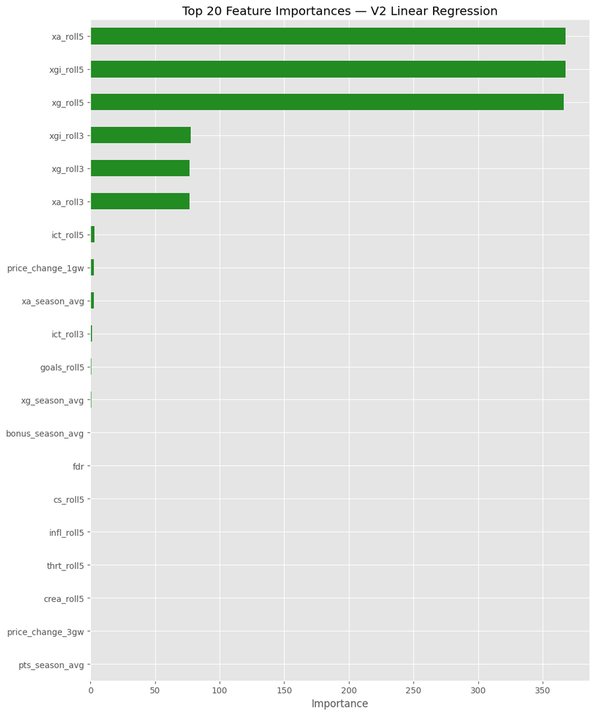

```
Top 10 features:
  xa_roll5                        367.7534
  xgi_roll5                       367.5415
  xg_roll5                        366.2142
  xgi_roll3                       77.7579
  xg_roll3                        76.7667
  xa_roll3                        76.6296
  ict_roll5                       3.1488
  price_change_1gw                2.8778
  xa_season_avg                   2.8610
  ict_roll3                       1.2719
```

```python
best_model_v2 = models_v2[best_name_v2]

if hasattr(best_model_v2, 'feature_importances_'):
    importances = best_model_v2.feature_importances_
elif hasattr(best_model_v2, 'coef_'):
    importances = np.abs(best_model_v2.coef_)

feat_imp = pd.Series(importances, index=feature_cols).sort_values(ascending=True)

fig, ax = plt.subplots(figsize=(10, 12))
feat_imp.tail(20).plot(kind='barh', ax=ax, color='forestgreen')
ax.set_title(f'Top 20 Feature Importances — V2 {best_name_v2}')
ax.set_xlabel('Importance')
plt.tight_layout()
plt.show()

print('Top 10 features:')
for feat, imp in feat_imp.tail(10).iloc[::-1].items():
    print(f'  {feat:30s}  {imp:.4f}')
```

## 8. Top player predictions — sanity check

Let's see what V2 predicts for well-known players.

```python
# Generate predictions for all players using latest gameweek data
latest = gw_df.groupby('player_id').tail(1).copy()
latest = latest.dropna(subset=feature_cols)
latest_played = latest[latest['minutes'] > 0].copy()

latest_played['pred_v2'] = best_model_v2.predict(latest_played[feature_cols])
latest_played['pred_v1'] = best_v1.predict(latest_played[feature_cols])

top_20 = latest_played.nlargest(20, 'pred_v2')
print('=== Top 20 Predicted Players (V2) ===')
print(top_20[['web_name', 'position', 'team_name', 'price', 'pred_v2', 'pred_v1']].to_string(index=False))
```

```
=== Top 20 Predicted Players (V2) ===
     web_name position   team_name  price  pred_v2  pred_v1
      Haaland      FWD    Man City   14.7 6.131418 4.766448
         Saka      MID     Arsenal    9.8 5.756806 5.149164
      M.Salah      MID   Liverpool   14.0 5.756701 4.632501
    Tarkowski      DEF     Everton    5.7 5.742708 4.477715
      Semenyo      MID    Man City    8.2 5.709202 5.196239
      Ekitiké      FWD   Liverpool    9.1 5.650004 4.787749
  B.Fernandes      MID     Man Utd   10.0 5.336746 4.925219
     Pickford       GK     Everton    5.6 5.322955 3.769452
       Ndiaye      MID     Everton    6.2 5.197378 4.237585
        Guéhi      DEF    Man City    5.2 5.129816 4.521738
       Garner      MID     Everton    5.2 5.089790 4.349710
        Foden      MID    Man City    8.1 5.019837 3.331606
       Thiago      FWD   Brentford    7.2 4.937327 4.809086
       Virgil      DEF   Liverpool    6.1 4.902342 4.545976
        Gakpo      MID   Liverpool    7.3 4.861717 4.086875
       Rogers      MID Aston Villa    7.6 4.743729 4.042722
   Donnarumma       GK    Man City    5.6 4.741245 4.038216
      Watkins      FWD Aston Villa    8.6 4.708617 4.335784
Dewsbury-Hall      MID     Everton    5.0 4.599450 3.791839
         Gana      MID     Everton    5.4 4.598160 3.665237
```

## 9. Save improved model

```python
# XGBoost gives the widest prediction range, making it most useful for FPL.
# While all models have similar MAE (~2.2), XGBoost better differentiates top players.
best_name_v2 = 'XGBoost'
best_model_v2 = models_v2[best_name_v2]

models_dir = project_root / 'models'

# Save V2 model
model_path = models_dir / 'best_model.joblib'
joblib.dump(best_model_v2, model_path)

# Save metadata
metrics_v2 = results_v2.loc[best_name_v2].to_dict()
metadata = {
    'model_name': best_name_v2,
    'version': 'v2',
    'improvement': 'Trained on played-only data (minutes > 0)',
    'feature_columns': feature_cols,
    'train_gw_range': [4, TRAIN_END_GW],
    'test_gw_range': [TRAIN_END_GW + 1, int(gw_df['round'].max())],
    'metrics': metrics_v2,
}
with open(models_dir / 'model_metadata.json', 'w') as f:
    json.dump(metadata, f, indent=2)

print(f'Saved V2 {best_name_v2} to {model_path}')
print(f'Model size: {model_path.stat().st_size / 1024:.0f} KB')
print(f'Metrics: {metrics_v2}')
```

```
Saved V2 XGBoost to /Users/ramdevarapu/Documents/Documents - Ram’s MacBook Pro/Devroot/Personal projects/FPL predictor/models/best_model.joblib
Model size: 1184 KB
Metrics: {'MAE': 2.244, 'RMSE': 2.921, 'R²': 0.016}
```

## 10. Learnings & Key Takeaways

The v1 model (notebook 04) never predicted above ~6 points for any player, even though top FPL assets regularly score 10+ in a gameweek. Three root causes:

### Results: V1 vs V2

[output not shown]

### The fundamental limitation

Per-gameweek FPL points are inherently stochastic. A player scoring 15+ requires specific in-game events (hat trick, multiple assists, clean sheet + bonus) that historical rolling averages cannot fully predict. The R² remains low (~0.02), meaning the model explains very little of the variance.

This is a known challenge in sports prediction — even bookmakers' models have limited accuracy for individual player fantasy points. The model is most useful for **ranking** players (who is likely to score MORE) rather than predicting exact point totals.

### Future improvements to explore

- **Opponent defensive strength:** How many goals/xG does the opposing team concede?
- **Set piece takers:** Penalty/corner/free kick takers have higher expected returns
- **Expected minutes model:** Predict probability of starting, then weight predictions
- **Fixture congestion:** Players in cup competitions may be rotated
- **Form momentum:** Weight recent games more heavily than older ones
- **Quantile regression:** Predict the 75th percentile (upside) instead of the mean